# Exemplary data analysis

Author

Julius Fenn

Published

May 10, 2025

# Background Information

This file contains the pre-processing step (clean, transform data), and the analysis step (test hypotheses and exploratory analyses). In larger projects you would split this file into multiple subfiles like data processing and data analyses steps, which follows the classical data-analysis pipeline (see Peng and Matsui 2016; Wickham and Grolemund 2017).

# Notes

Remark:

```r
## global variables
cutOff <- 1 # cutoff value for building extreme groups
```

# get packages, raw data, functions

```r
### install and load packages
#  if packages are not already installed, the function will install and activate them
usePackage <- function(p) {
  if (!is.element(p, installed.packages()[,1]))
    install.packages(p, dep = TRUE, repos = "http://cran.us.r-project.org")
  require(p, character.only = TRUE)
}

usePackage("haven") # load SPSS, ... data
usePackage("tidyverse") # data cleaning and summarizing
usePackage("psych") # psychometric analysis (EFA)

## psychometric analysis
usePackage("moments") # skewness, kurtosis

## outputs
usePackage("stargazer") # create tables
usePackage("report") # get reports of statistical tests in APA7

usePackage("lavaan") # for CFA

rm(usePackage)


### load data files
## change working directory
setwd("data")
## load data
dat <- haven::read_spss(file = "ESS1-9e01_1.sav")


### load functions
# print(getwd())
setwd("../functions")
for(i in 1:length(dir())){
  # print(dir()[i])
  source(dir()[i], encoding = "utf-8")
}

rm(i)
```

# data preperation

compute mean scores

```r
### data preparation
dat$cntry <- NULL

# reverse coded items
dat$imsmetn <- 5 - dat$imsmetn
dat$imdfetn <- 5 - dat$imdfetn
dat$impcntr <- 5 - dat$impcntr


### create mean scores
# !!! normally you would need to run multiple analysis to check if building mean scores make sense (EFAs, ...)

# > Immigration bad or good for country's economy
# > Country's cultural life undermined or enriched by immigrants
# > Immigrants make country worse or better place to live
sel_var <- c("imbgeco", "imueclt", "imwbcnt")
dat$mean_imEnrich <- rowMeans(x = dat[, sel_var], na.rm = TRUE)
# > Allow many/few immigrants of same race/ethnic group as majority
# > Allow many/few immigrants of different race/ethnic group from majority
# > Allow many/few immigrants from poorer countries outside Europe
sel_var <- c("imsmetn", "imdfetn", "impcntr")
dat$mean_imAllow <- rowMeans(x = dat[, sel_var], na.rm = TRUE)
# > Trust
sel_var <- str_detect(string = colnames(dat), pattern = "^trst")
dat$mean_trst <- rowMeans(x = dat[, sel_var], na.rm = TRUE)
# > Satisfaction (personally, government)
sel_var <- str_detect(string = colnames(dat), pattern = "^stf")
dat$mean_stf <- rowMeans(x = dat[, sel_var], na.rm = TRUE)
dat$sd_stf <- dat %>%
  select(matches(match = "^stf")) %>%
  apply(.,1, sd, na.rm = TRUE)
```

## get extreme groups for `lrscale` variable

Aim to get two extreme groups according to the `lrscale` (left, right scale) variable:

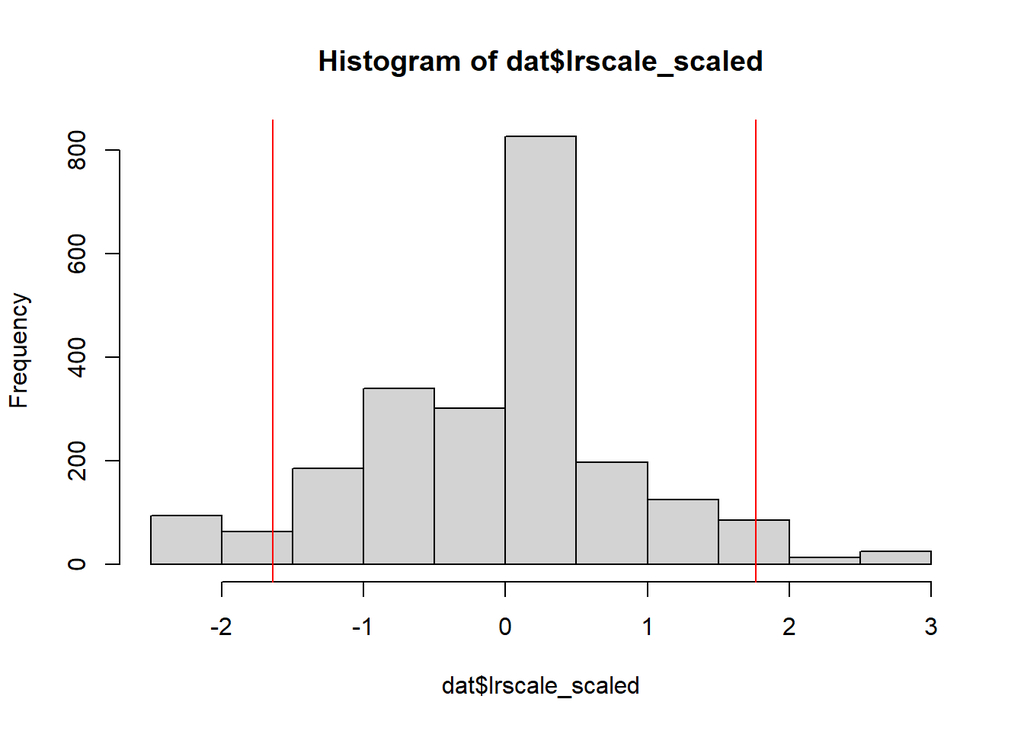

```r
dat$lrscale_scaled <- scale(x = dat$lrscale, center = TRUE, scale = TRUE)
mean_upper <- mean(dat$lrscale_scaled[dat$lrscale_scaled > cutOff], na.rm = TRUE)
mean_lower <- mean(dat$lrscale_scaled[dat$lrscale_scaled < cutOff * -1], na.rm = TRUE)
hist(dat$lrscale_scaled)
# add vertical line
abline(v=mean_upper, col = "red")
abline(v=mean_lower, col = "red")
```

```r
# save subsets
dat_upper <-dat %>%
  filter(dat$lrscale_scaled > mean_upper)
dat_lower <-dat %>%
  filter(dat$lrscale_scaled < mean_lower)


### get dummy
dat$lrscale_dummy <- ifelse(test = dat$lrscale_scaled > mean_upper, yes = 2, no =
         ifelse(test = dat$lrscale_scaled < mean_lower, yes = 1, no = 0))
table(dat$lrscale_dummy)
```

```
   0    1    2
1977  159  125
```

# Introduction

Migration ‘mother of all political problems,’ says German Interior Minister Horst Seehofer. Hort Seehofer’s 2018 statement[^1] after the protests in Chemnitz, which sees migration at the heart of society’s disillusionment, shows how charged the debate about migration is in Germany.

# Background

# Quoting (please remove this for your report!)

# Methods

## Hypothesis

**Are different factors relevant to the perceived threat of migrants by people with a high or low left/right orientation?**

# Results

## Descriptive Statisticss

First glimpse at the loaded data:

```r
glimpse(dat)
```

```
Rows: 2,358
Columns: 41
$ cname          <chr> "ESS1-9e01", "ESS1-9e01", "ESS1-9e01", "ESS1-9e01", "ES…
$ cedition       <chr> "1.0", "1.0", "1.0", "1.0", "1.0", "1.0", "1.0", "1.0",…
$ cproddat       <chr> "10.12.2020", "10.12.2020", "10.12.2020", "10.12.2020",…
$ cseqno         <dbl> 101403, 101404, 101405, 101406, 101407, 101408, 101409,…
$ name           <chr> "ESS9e03", "ESS9e03", "ESS9e03", "ESS9e03", "ESS9e03", …
$ essround       <dbl+lbl> 9, 9, 9, 9, 9, 9, 9, 9, 9, 9, 9, 9, 9, 9, 9, 9, 9, …
$ edition        <chr> "3", "3", "3", "3", "3", "3", "3", "3", "3", "3", "3", …
$ idno           <dbl> 9, 10, 64, 65, 91, 119, 150, 212, 255, 270, 279, 304, 3…
$ dweight        <dbl> 0.9994662, 0.9994662, 0.9994662, 0.9994662, 0.9994662, …
$ pspwght        <dbl> 1.2750090, 0.8540229, 0.7596949, 1.0794106, 1.2697877, …
$ pweight        <dbl> 3.037345, 3.037345, 3.037345, 3.037345, 3.037345, 3.037…
$ anweight       <dbl> 3.872642, 2.593962, 2.307456, 3.278542, 3.856783, 3.872…
$ trstprl        <dbl+lbl>  2,  7,  3,  3,  4,  9, 10,  5,  5,  7, NA,  6,  6,…
```

[output cut: 28 more lines]

```r
summary(dat)
```

```
    cname             cedition           cproddat             cseqno
 Length:2358        Length:2358        Length:2358        Min.   :101403
 Class :character   Class :character   Class :character   1st Qu.:101992
 Mode  :character   Mode  :character   Mode  :character   Median :102582
                                                          Mean   :102582
                                                          3rd Qu.:103171
                                                          Max.   :103760

     name              essround   edition               idno
 Length:2358        Min.   :9   Length:2358        Min.   :    9
 Class :character   1st Qu.:9   Class :character   1st Qu.:17194
 Mode  :character   Median :9   Mode  :character   Median :34640
                    Mean   :9                      Mean   :34894
                    3rd Qu.:9                      3rd Qu.:52408
                    Max.   :9                      Max.   :69956

    dweight          pspwght          pweight         anweight
 Min.   :0.9995   Min.   :0.4300   Min.   :3.037   Min.   : 1.306
 1st Qu.:0.9995   1st Qu.:0.7410   1st Qu.:3.037   1st Qu.: 2.251
 Median :0.9995   Median :0.9423   Median :3.037   Median : 2.862
 Mean   :1.0000   Mean   :1.0000   Mean   :3.037   Mean   : 3.037
 3rd Qu.:0.9995   3rd Qu.:1.1026   3rd Qu.:3.037   3rd Qu.: 3.349
 Max.   :1.6288   Max.   :3.7891   Max.   :3.037   Max.   :11.509

    trstprl          trstlgl          trstplc          trstplt
 Min.   : 0.000   Min.   : 0.000   Min.   : 0.000   Min.   : 0.000
 1st Qu.: 3.000   1st Qu.: 5.000   1st Qu.: 6.000   1st Qu.: 2.000
 Median : 5.000   Median : 7.000   Median : 8.000   Median : 4.000
 Mean   : 5.099   Mean   : 6.128   Mean   : 7.103   Mean   : 3.964
 3rd Qu.: 7.000   3rd Qu.: 8.000   3rd Qu.: 9.000   3rd Qu.: 6.000
 Max.   :10.000   Max.   :10.000   Max.   :10.000   Max.   :10.000
 NA's   :31       NA's   :21       NA's   :5        NA's   :19
    trstprt           trstep           trstun          lrscale
 Min.   : 0.000   Min.   : 0.000   Min.   : 0.000   Min.   : 0.000
 1st Qu.: 2.000   1st Qu.: 3.000   1st Qu.: 3.000   1st Qu.: 3.000
 Median : 4.000   Median : 5.000   Median : 5.000   Median : 5.000
 Mean   : 3.993   Mean   : 4.562   Mean   : 4.903   Mean   : 4.388
 3rd Qu.: 5.000   3rd Qu.: 6.000   3rd Qu.: 7.000   3rd Qu.: 5.000
 Max.   :10.000   Max.   :10.000   Max.   :10.000   Max.   :10.000
 NA's   :22       NA's   :81       NA's   :104      NA's   :97
```

[output cut: 33 more lines]

```
 Min.   : 0.000   Min.   : 0.250   Min.   :0.000   Min.   :-2.30234
 1st Qu.: 3.857   1st Qu.: 5.250   1st Qu.:1.258   1st Qu.:-0.72823
 Median : 5.286   Median : 6.250   Median :1.893   Median : 0.32118
 Mean   : 5.116   Mean   : 6.163   Mean   :1.982   Mean   : 0.00000
 3rd Qu.: 6.571   3rd Qu.: 7.250   3rd Qu.:2.630   3rd Qu.: 0.32118
 Max.   :10.000   Max.   :10.000   Max.   :6.364   Max.   : 2.94470
 NA's   :2        NA's   :1        NA's   :9       NA's   :97
 lrscale_dummy.V1
 Min.   :0.00000
 1st Qu.:0.00000
 Median :0.00000
 Mean   :0.18089
 3rd Qu.:0.00000
 Max.   :2.00000
 NA's   :97
```

## Basic Inferential Statisticss

Combining statistical tests like cor.test or t.test with the respective plot, check the assumptions of every test procedure you are using:

```r
cor.test(dat$mean_stf, dat$mean_imEnrich, use = "complete")
```

```
    Pearson's product-moment correlation

data:  dat$mean_stf and dat$mean_imEnrich
t = 21.905, df = 2346, p-value < 2.2e-16
alternative hypothesis: true correlation is not equal to 0
95 percent confidence interval:
 0.3779243 0.4451088
sample estimates:
      cor
0.4120765
```

```r
report::report(cor.test(dat$mean_stf, dat$mean_imEnrich, use = "complete"))
```

```
Effect sizes were labelled following Funder's (2019) recommendations.

The Pearson's product-moment correlation between dat$mean_stf and
dat$mean_imEnrich is positive, statistically significant, and very large (r =
0.41, 95% CI [0.38, 0.45], t(2346) = 21.91, p < .001)
```

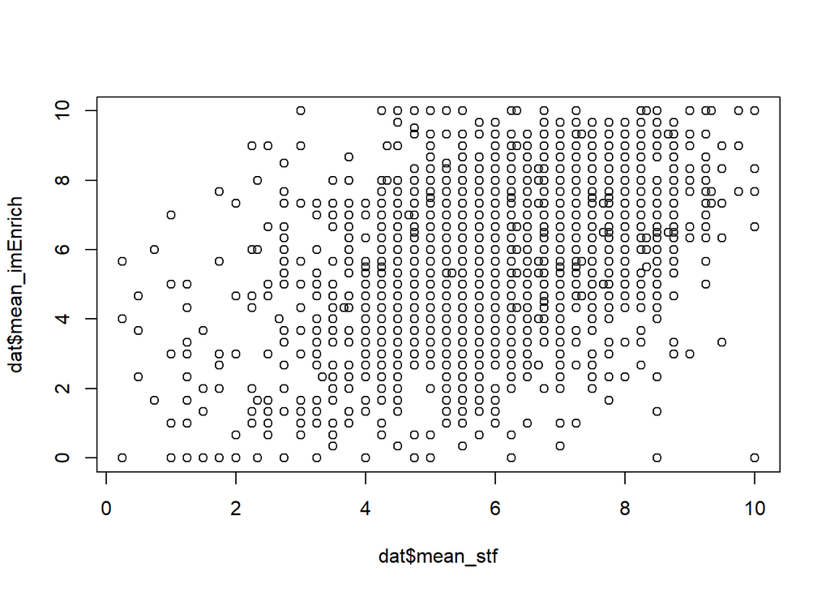

```r
plot(dat$mean_stf, dat$mean_imEnrich)
```

```r
t.test(dat$mean_stf ~ dat$gndr)
```

```
    Welch Two Sample t-test

data:  dat$mean_stf by dat$gndr
t = 1.8892, df = 2349.3, p-value = 0.05899
alternative hypothesis: true difference in means between group 1 and group 2 is not equal to 0
95 percent confidence interval:
 -0.004760463  0.255262839
sample estimates:
mean in group 1 mean in group 2
       6.223941        6.098690
```

```r
t.test(dat$mean_stf ~ dat$gndr, var.equal = TRUE)
```

```
    Two Sample t-test

data:  dat$mean_stf by dat$gndr
t = 1.8888, df = 2355, p-value = 0.05905
alternative hypothesis: true difference in means between group 1 and group 2 is not equal to 0
95 percent confidence interval:
 -0.004788142  0.255290517
sample estimates:
mean in group 1 mean in group 2
       6.223941        6.098690
```

```r
report::report(t.test(dat$mean_stf ~ dat$gndr))
```

```
Effect sizes were labelled following Cohen's (1988) recommendations.

The Welch Two Sample t-test testing the difference of dat$mean_stf by dat$gndr
(mean in group 1 = 6.22, mean in group 2 = 6.10) suggests that the effect is
positive, statistically not significant, and very small (difference = 0.13, 95%
CI [-4.76e-03, 0.26], t(2349.27) = 1.89, p = 0.059; Cohen's d = 0.08, 95% CI
[-2.96e-03, 0.16])
```

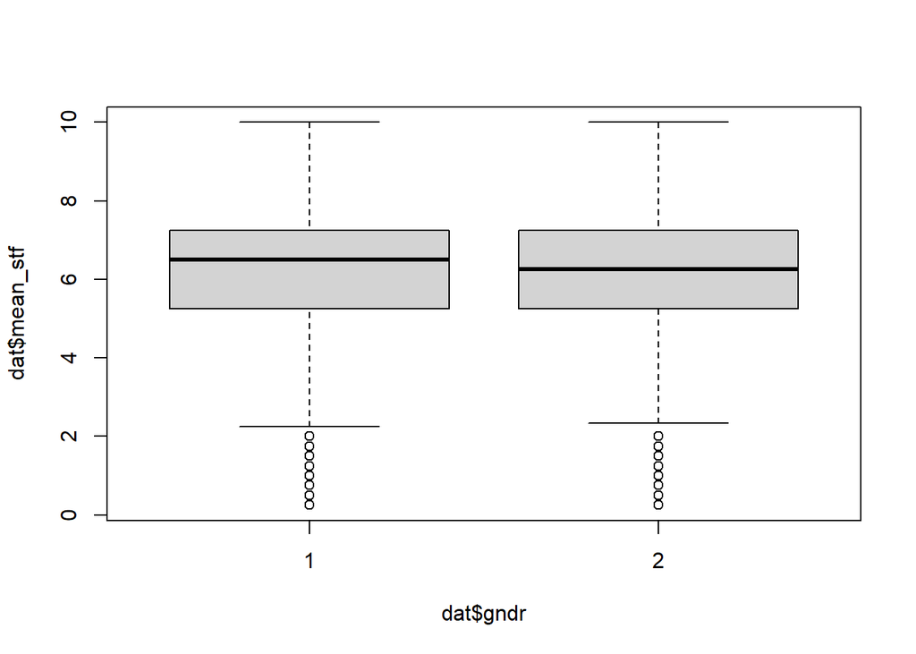

```r
boxplot(dat$mean_stf ~ dat$gndr)
```

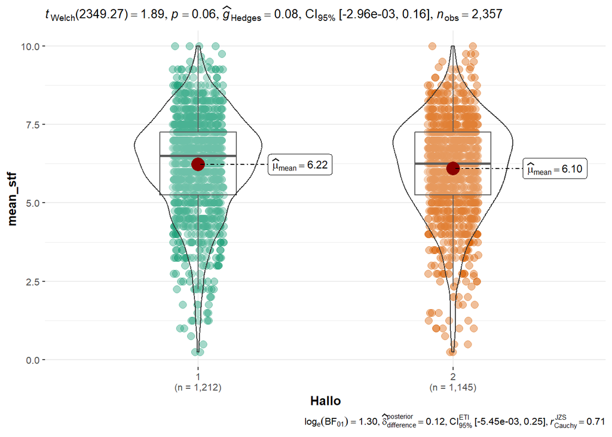

```r
p <- ggstatsplot::ggbetweenstats(data = dat, x = gndr, y = mean_stf)
p + xlab(label = "Hallo")
```

## analyses of extreme groups for lrscale variable

### Descriptive Statisticss

```r
tmp_desc <- dat %>%
  group_by(lrscale_dummy) %>%
  summarise(N = n(),
            meanEnrich = mean(mean_imEnrich, na.rm = TRUE),
            sdEnrich = sd(mean_imEnrich, na.rm = TRUE),
            meanAllow = mean(mean_imAllow, na.rm = TRUE),
            sdAllow = sd(mean_imAllow, na.rm = TRUE),
            meanStf = mean(mean_stf, na.rm = TRUE),
            sdStf = sd(mean_stf, na.rm = TRUE),
            meanTrst = mean(mean_trst, na.rm = TRUE),
            sdTrst = sd(mean_trst, na.rm = TRUE))
tmp_desc <- round(x = tmp_desc, digits = 2)

tmp_desc
```

```
# A tibble: 4 × 10
  lrscale_dummy[,1]     N meanEnrich sdEnrich meanAllow sdAllow meanStf sdStf
              <dbl> <dbl>      <dbl>    <dbl>     <dbl>   <dbl>   <dbl> <dbl>
1                 0  1977       5.9      1.99      3.04    0.64    6.2   1.55
2                 1   159       6.34     2.06      3.24    0.69    5.9   1.67
3                 2   125       4.72     2.57      2.73    0.65    6.1   1.82
4                NA    97       5.11     2.42      2.87    0.78    5.91  2.32
# ℹ 2 more variables: meanTrst <dbl>, sdTrst <dbl>
```

Using the **stargazer** package you can create nice tables. You sometimes need to limit the number of digits using the function round():

```r
### set up summary dataset yourself
stargazer(tmp_desc, type = "html", summary = FALSE)
```

|  | lrscale_dummy | N | meanEnrich | sdEnrich | meanAllow | sdAllow | meanStf | sdStf | meanTrst | sdTrst |
| --- | --- | --- | --- | --- | --- | --- | --- | --- | --- | --- |
| 1 | 0 | 1977 | 5.9 | 1.99 | 3.04 | 0.64 | 6.2 | 1.55 | 5.18 | 1.76 |
| 2 | 1 | 159 | 6.34 | 2.06 | 3.24 | 0.69 | 5.9 | 1.67 | 4.86 | 1.94 |
| 3 | 2 | 125 | 4.72 | 2.57 | 2.73 | 0.65 | 6.1 | 1.82 | 4.72 | 2.04 |
| 4 | NA | 97 | 5.11 | 2.42 | 2.87 | 0.78 | 5.91 | 2.32 | 4.65 | 2.25 |

```r
### using summary function within stargazer
tmp_desc_stargazeer <- as.data.frame(dat[, str_subset(string = colnames(dat), pattern = "mean_")])
tmp_desc_stargazeer <- na.omit(tmp_desc_stargazeer)
stargazer(x =tmp_desc_stargazeer, type = "html", summary = TRUE, digits = 2)
```

| Statistic | N | Mean | St. Dev. | Min | Max |
| --- | --- | --- | --- | --- | --- |
| mean_imEnrich | 2,335 | 5.84 | 2.07 | 0.00 | 10.00 |
| mean_imAllow | 2,335 | 3.03 | 0.66 | 1.00 | 4.00 |
| mean_trst | 2,335 | 5.12 | 1.81 | 0.00 | 10.00 |
| mean_stf | 2,335 | 6.17 | 1.60 | 0.25 | 10.00 |

```
#> output to html
```

```r
setwd("outputs")
stargazer(tmp_desc, type = "html", summary = FALSE, out = "summaryTable.html")
```

|  | lrscale_dummy | N | meanEnrich | sdEnrich | meanAllow | sdAllow | meanStf | sdStf | meanTrst | sdTrst |
| --- | --- | --- | --- | --- | --- | --- | --- | --- | --- | --- |
| 1 | 0 | 1977 | 5.9 | 1.99 | 3.04 | 0.64 | 6.2 | 1.55 | 5.18 | 1.76 |
| 2 | 1 | 159 | 6.34 | 2.06 | 3.24 | 0.69 | 5.9 | 1.67 | 4.86 | 1.94 |
| 3 | 2 | 125 | 4.72 | 2.57 | 2.73 | 0.65 | 6.1 | 1.82 | 4.72 | 2.04 |
| 4 | NA | 97 | 5.11 | 2.42 | 2.87 | 0.78 | 5.91 | 2.32 | 4.65 | 2.25 |

### Basic Inferential Statisticss

```r
lm_lower <- lm(formula = mean_imEnrich ~ mean_trst + mean_stf + happy + agea + gndr, data = dat_lower)
lm_upper <- lm(formula = mean_imEnrich ~ mean_trst + mean_stf + happy + agea + gndr, data = dat_upper)
summary(lm_lower)
```

```
Call:
lm(formula = mean_imEnrich ~ mean_trst + mean_stf + happy + agea +
    gndr, data = dat_lower)

Residuals:
    Min      1Q  Median      3Q     Max
-5.3869 -1.0797  0.0966  1.1228  4.0886

Coefficients:
             Estimate Std. Error t value Pr(>|t|)
(Intercept)  5.172446   0.911014   5.678 6.73e-08 ***
mean_trst    0.451803   0.102439   4.410 1.94e-05 ***
mean_stf    -0.182405   0.131175  -1.391    0.166
happy        0.105915   0.094284   1.123    0.263
agea        -0.001638   0.007501  -0.218    0.827
gndr        -0.451923   0.321711  -1.405    0.162
---
Signif. codes:  0 '***' 0.001 '**' 0.01 '*' 0.05 '.' 0.1 ' ' 1

Residual standard error: 1.939 on 152 degrees of freedom
  (1 Beobachtung als fehlend gelöscht)
Multiple R-squared:  0.1389,    Adjusted R-squared:  0.1106
F-statistic: 4.905 on 5 and 152 DF,  p-value: 0.0003442
```

```r
summary(lm_upper)
```

```
Call:
lm(formula = mean_imEnrich ~ mean_trst + mean_stf + happy + agea +
    gndr, data = dat_upper)

Residuals:
    Min      1Q  Median      3Q     Max
-4.7007 -1.6438  0.1496  1.4679  6.7869

Coefficients:
            Estimate Std. Error t value Pr(>|t|)
(Intercept) -1.28886    1.13532  -1.135  0.25856
mean_trst    0.28955    0.13520   2.142  0.03427 *
mean_stf     0.53544    0.16619   3.222  0.00164 **
happy       -0.00867    0.10892  -0.080  0.93669
agea         0.01027    0.01021   1.007  0.31620
gndr         0.61951    0.38910   1.592  0.11400
---
Signif. codes:  0 '***' 0.001 '**' 0.01 '*' 0.05 '.' 0.1 ' ' 1

Residual standard error: 2.122 on 119 degrees of freedom
Multiple R-squared:  0.3445,    Adjusted R-squared:  0.317
F-statistic: 12.51 on 5 and 119 DF,  p-value: 9.165e-10
```

Again we can use the **stargazer** package, which identifies `lm_upper` for example as an lm-object in R and creates a wonderful table for the model results:

```r
stargazer(lm_lower, type = "html")
```

|  | *Dependent variable:* |
| --- | --- |
|  | mean_imEnrich |
| mean_trst | 0.452*** |
|  | (0.102) |
| mean_stf | -0.182 |
|  | (0.131) |
| happy | 0.106 |
|  | (0.094) |
| agea | -0.002 |
|  | (0.008) |
| gndr | -0.452 |
|  | (0.322) |
| Constant | 5.172*** |
|  | (0.911) |
| Observations | 158 |
| R<sup>2</sup> | 0.139 |
| Adjusted R<sup>2</sup> | 0.111 |
| Residual Std. Error | 1.939 (df = 152) |
| F Statistic | 4.905*** (df = 5; 152) |
| *Note:* | *p<0.1; **p<0.05;*** p<0.01 |

```r
stargazer(lm_upper, type = "html")
```

|  | *Dependent variable:* |
| --- | --- |
|  | mean_imEnrich |
| mean_trst | 0.290** |
|  | (0.135) |
| mean_stf | 0.535*** |
|  | (0.166) |
| happy | -0.009 |
|  | (0.109) |
| agea | 0.010 |
|  | (0.010) |
| gndr | 0.620 |
|  | (0.389) |
| Constant | -1.289 |
|  | (1.135) |
| Observations | 125 |
| R<sup>2</sup> | 0.345 |
| Adjusted R<sup>2</sup> | 0.317 |
| Residual Std. Error | 2.122 (df = 119) |
| F Statistic | 12.511*** (df = 5; 119) |
| *Note:* | *p<0.1; **p<0.05;*** p<0.01 |

# Appendix

## Test for unidimensionality, CFA

Here we could apply a self-written function for example to check the reliability and amount of explained variance for the first factor:

*get correlation plot, descriptive plot, EFA, CFA*

```r
regEx <- "^trst"
nameScale <- "Trust Scale"
nameVariable <- "mean_TrustItems"

sum(str_detect(string = colnames(dat), pattern = regEx))
```

```
[1] 7
```

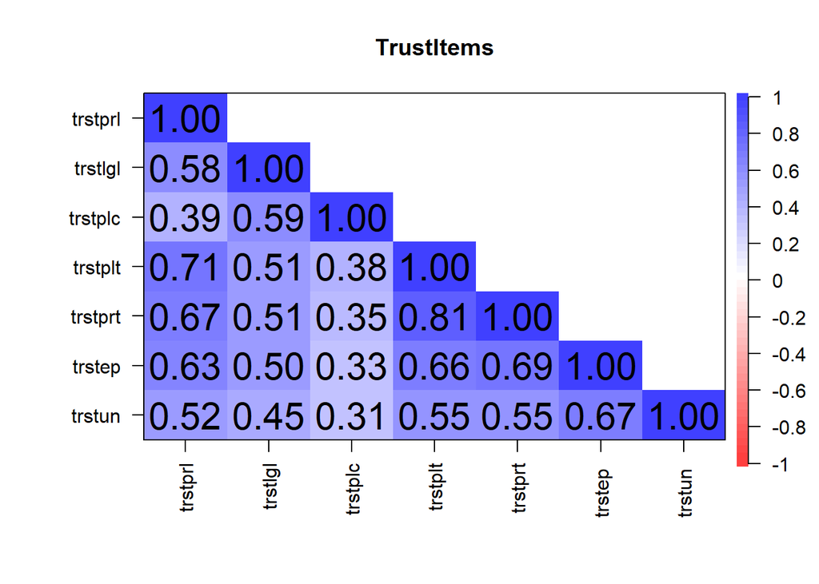

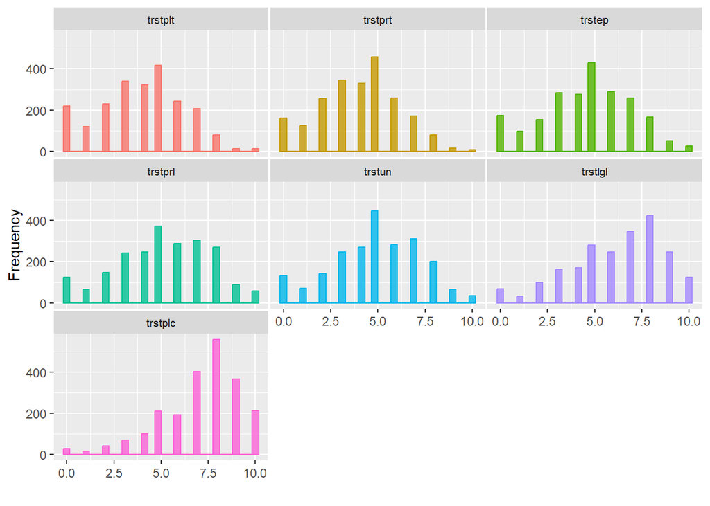

```
descriptive statistics:
        Mean   SD Median CoeffofVariation Minimum Maximun Lower Quantile
trstprl 5.13 2.47      5             0.48       0      10              0
trstlgl 6.16 2.48      7             0.40       0      10              0
trstplc 7.10 2.14      8             0.30       0      10              0
trstplt 3.97 2.25      4             0.57       0      10              0
trstprt 4.02 2.13      4             0.53       0      10              0
trstep  4.58 2.39      5             0.52       0      10              0
trstun  4.91 2.35      5             0.48       0      10              0
        Upper Quantile Skewness Kurtosis(-3) KS-Test
trstprl             10    -0.25        -0.57       0
trstlgl             10    -0.58        -0.33       0
trstplc             10    -1.02         0.91       0
trstplt             10    -0.05        -0.60       0
trstprt             10    -0.05        -0.50       0
trstep              10    -0.18        -0.55       0
trstun              10    -0.25        -0.44       0


variables under investigation:  trstprl trstlgl trstplc trstplt trstprt trstep trstun

Cronbachs Alpha: 0.89
Error in polychoric(x, correct = correct) :
  You have more than8 categories for your items, polychoric is probably not needed
[1] "use instead of polychoric correlations pearson correlations"
```

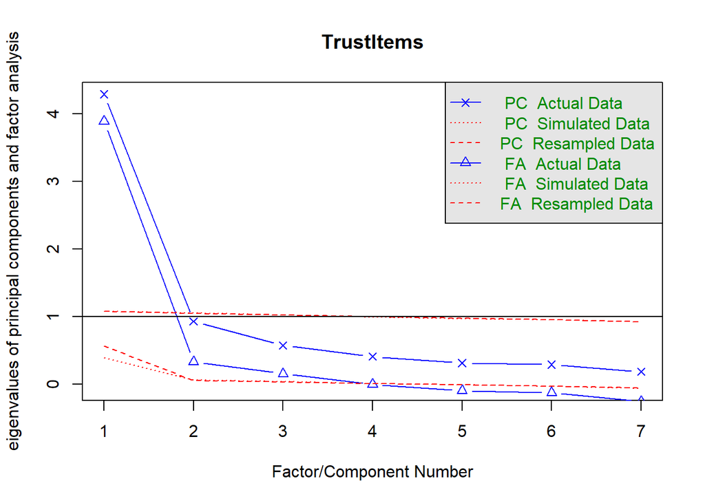

```
Parallel analysis suggests that the number of factors =  3  and the number of components =  1
TrustItems
Number of components:  1

Error in polychoric(tmp_dat) :
  You have more than8 categories for your items, polychoric is probably not needed
[1] "use instead of polychoric correlations pearson correlations"


EFA factor loadings (1 factor solution):

Loadings:
        MR1
trstprl 0.806
trstlgl 0.678
trstplc 0.495
trstplt 0.850
trstprt 0.838
trstep  0.802
trstun  0.685

                 MR1
SS loadings    3.892
Proportion Var 0.556
CFA summary and fit statistics:
lavaan 0.6.17 ended normally after 28 iterations

  Estimator                                         ML
  Optimization method                           NLMINB
  Number of model parameters                        14

  Number of observations                          2202

Model Test User Model:
                                              Standard      Scaled
  Test Statistic                               964.099     547.943
  Degrees of freedom                                14          14
  P-value (Chi-square)                           0.000       0.000
  Scaling correction factor                                  1.759
    Yuan-Bentler correction (Mplus variant)
```

[output cut: 59 more lines]

```
    trstplt           0.997    0.021   47.008    0.000    1.972    0.877
    trstprt           0.933    0.022   42.309    0.000    1.846    0.868
    trstep            0.957    0.023   41.358    0.000    1.893    0.793
    trstun            0.800    0.025   31.400    0.000    1.582    0.673

Variances:
                   Estimate  Std.Err  z-value  P(>|z|)   Std.lv  Std.all
   .trstprl           2.193    0.113   19.485    0.000    2.193    0.359
   .trstlgl           3.633    0.127   28.590    0.000    3.633    0.593
   .trstplc           3.615    0.131   27.681    0.000    3.615    0.786
   .trstplt           1.163    0.077   15.008    0.000    1.163    0.230
   .trstprt           1.118    0.071   15.803    0.000    1.118    0.247
   .trstep            2.119    0.102   20.683    0.000    2.119    0.371
   .trstun            3.029    0.119   25.373    0.000    3.029    0.548
    TrustItems        3.914    0.168   23.347    0.000    1.000    1.000
```

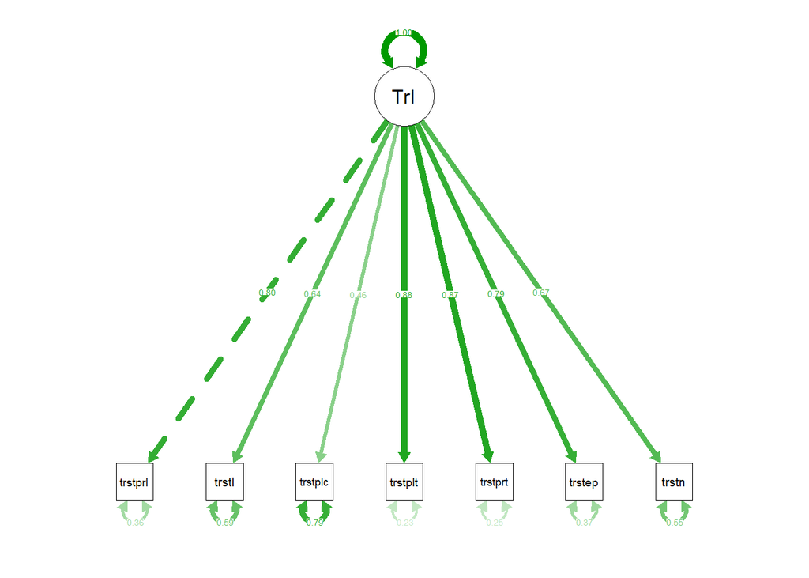

```
CFA first 6 Modification Indices:
       lhs op     rhs      mi    epc sepc.lv sepc.all sepc.nox
22 trstlgl ~~ trstplc 438.788  1.692   1.692    0.467    0.467
36  trstep ~~  trstun 271.209  1.023   1.023    0.404    0.404
31 trstplt ~~ trstprt 259.067  0.703   0.703    0.616    0.616
16 trstprl ~~ trstlgl  70.977  0.580   0.580    0.206    0.206
33 trstplt ~~  trstun  59.919 -0.404  -0.404   -0.215   -0.215
32 trstplt ~~  trstep  55.450 -0.366  -0.366   -0.233   -0.233
```

```r
tmp_dat <- na.omit(dat[,str_detect(string = colnames(dat), pattern = regEx)])


tmp <- CFAstats(dataset = tmp_dat, regularExp = regEx, labelLatent = str_remove(string = nameVariable, pattern = "mean_"),
                showPlots = TRUE,
                computeEFA = TRUE,
                computeCFA = TRUE,
                computeCFAMplus = FALSE)
```

# Save final files

```r
setwd("outputs")
## save as .xlsx file
xlsx::write.xlsx2(x = dat, file = "dat.xlsx")
## save as .csv file
write.csv2(x = dat, file = "dat.csv")
## save as R object
saveRDS(dat, file = "dat.rds")
```

## References

Newman, Mark. 2018. *Networks: An Introduction*. Oxford University Press.

Peng, Roger D., and Elizabeth Matsui. 2016. *The Art of Data Science: A Guide for Anyone Who Works with Data*. Lulu.com. https://bookdown.org/rdpeng/artofdatascience/.

Skrondal, Anders, and Sophia Rabe-Hesketh. 2004. *Generalized Latent Variable Modeling: Multilevel, Longitudinal, and Structural Equation Models*. New York: Chapman; Hall/CRC. https://doi.org/10.1201/9780203489437.

Wickham, Hadley, and Garrett Grolemund. 2017. *R for Data Science: Import, Tidy, Transform, Visualize, and Model Data*. "O’Reilly Media, Inc.". https://r4ds.had.co.nz/.

Xie, Yihui, J. J. Allaire, and Garrett Grolemund. 2018. *R Markdown: The Definitive Guide*. New York: Chapman; Hall/CRC. https://doi.org/10.1201/9781138359444.

## Footnotes

[^1]: see https://www.dw.com/en/migration-mother-of-all-political-problems-says-german-interior-minister-horst-seehofer/a-45378092, retrieved 9 February 2022